# Projects Tracking and Management - Case Study

## Introduction

#### Background

> I have been provided a dataset that contains logged Hours by employees on Projects and SW Tickets opened on these projects to be solved.

#### Dataset

- Hours.
- Engineering.

## Required Libraries

```python
import numpy as np # linear algebra
import pandas as pd # data processing, CSV file I/O (e.g. pd.read_excel)
import matplotlib.pyplot as plt
import seaborn as sns
import warnings
warnings.filterwarnings('ignore')
%matplotlib inline
```

## Load Data

```python
# Loding the dataset with pandas
Hours_df = pd.read_excel(r'Use Case.xlsx','Hours')
Engineering_df = pd.read_excel(r'Use Case.xlsx','Engineering')
```

## Discovery

```python
# Display sample from data to Discover it
display(Hours_df.sample(5))
display(Engineering_df.sample(5))
```

|  | Project Code | Project_Status | Calendar | Hours | Week | Forecasted hours | Budget Hours | Service type | Period_From | Period_To | Cost Rate | Department |
| --- | --- | --- | --- | --- | --- | --- | --- | --- | --- | --- | --- | --- |
| 25517 | 9WK1582 | Open | EG_02 | 5.0 | 2022_W32 | 29.0 | 7.0 | Overheads | 2022_W24 | 2022_W42 | 33.32 | Internal |
| 19674 | 1WK1736 | Under Development | EG_02 | 32.0 | 2022_W25 | 35.0 | 1.0 | NaN | 2022_W24 | 2022_W42 | 33.32 | Camera |
| 63988 | 1WK1116 | Under Development | EG_02 | 58.0 | 2022_W31 | 20.0 | 31.0 | NaN | 2022_W24 | 2022_W42 | 33.32 | Camera |
| 40089 | 0WK1200 | Under Development | EG_02 | 10.0 | 2022_W33 | 25.0 | 8.0 | NaN | 2022_W24 | 2022_W42 | 33.32 | Visibility |
| 60841 | 1WK1147 | Under Development | EG_02 | 20.0 | 2022_W27 | 29.0 | 6.0 | NaN | 2022_W24 | 2022_W42 | 33.32 | Camera |

|  | Ticket Number | Project Code | Start Date | End Date | Stage | Site | Severity | Ticket Origin |
| --- | --- | --- | --- | --- | --- | --- | --- | --- |
| 47272 | Tict47273 | E271273 | 2022-03-21 | 2022-10-26 | Closed | Russia | Red | Customer |
| 5445 | Tict5446 | 1WK2374 | 2022-02-28 | 2022-09-02 | Closed | Russia | Yellow | Customer |
| 14249 | Tict14250 | 1WK2313 | 2022-06-27 | 2022-10-19 | Closed | Russia | Red | Hardware |
| 39856 | Tict39857 | 1WK2316 | 2022-07-19 | 2022-10-18 | Cancelled | Russia | Orange | Hardware |
| 64314 | Tict64315 | 0WK1025 | 2022-01-27 | 2022-10-10 | Cancelled | Russia | Red | Mechanical |

```python
Hours_shape=Hours_df.shape
print('Hours Rows : ',Hours_shape[0])
print('Hours Columns : ',Hours_shape[1])
```

```
Hours Rows :  80349
Hours Columns :  12
```

```python
# Display information about data
Hours_df.info()
```

```
<class 'pandas.core.frame.DataFrame'>
RangeIndex: 80349 entries, 0 to 80348
Data columns (total 12 columns):
 #   Column            Non-Null Count  Dtype
---  ------            --------------  -----
 0   Project Code      80349 non-null  object
 1   Project_Status    80349 non-null  object
 2   Calendar          80349 non-null  object
 3   Hours             80349 non-null  float64
 4   Week              80349 non-null  object
 5   Forecasted hours  80349 non-null  float64
 6   Budget Hours      80349 non-null  float64
 7   Service type      10393 non-null  object
 8   Period_From       80349 non-null  object
 9   Period_To         80349 non-null  object
 10  Cost Rate         80349 non-null  float64
 11  Department        80349 non-null  object
dtypes: float64(4), object(8)
memory usage: 7.4+ MB
```

```python
Hours_df.isna().sum()
```

```
Project Code            0
Project_Status          0
Calendar                0
Hours                   0
Week                    0
Forecasted hours        0
Budget Hours            0
Service type        69956
Period_From             0
Period_To               0
Cost Rate               0
Department              0
dtype: int64
```

```python
Hours_df.groupby('Department')['Service type'].count()
```

```
Department
Camera              0
Innovation          0
Internal        10393
Power Strain        0
Services            0
Switches            0
Thermal             0
Tooling             0
Visibility          0
Wippers             0
Name: Service type, dtype: int64
```

```python
print('Projects Count Distinct : ',len(Hours_df['Project Code'].unique()))
```

```
Projects Count Distinct :  11028
```

```python
Hours_df.duplicated().sum()
```

```
8
```

```python
Hours_df.describe()
```

|  | Hours | Forecasted hours | Budget Hours | Cost Rate |
| --- | --- | --- | --- | --- |
| count | 80349.000000 | 80349.000000 | 80349.000000 | 8.034900e+04 |
| mean | 22.152024 | 20.466266 | 20.466677 | 3.332000e+01 |
| std | 15.198905 | 11.521039 | 11.531718 | 1.962531e-11 |
| min | 1.000000 | 1.000000 | 1.000000 | 3.332000e+01 |
| 25% | 8.000000 | 10.000000 | 10.000000 | 3.332000e+01 |
| 50% | 20.000000 | 20.000000 | 20.000000 | 3.332000e+01 |
| 75% | 40.000000 | 30.000000 | 30.000000 | 3.332000e+01 |
| max | 66.000000 | 40.000000 | 40.000000 | 3.332000e+01 |

```python
for x in Hours_df[['Department','Project_Status','Calendar']].columns :
    print(x,'unique Counts: ',Hours_df[x].nunique())
```

```
Department unique Counts:  10
Project_Status unique Counts:  6
Calendar unique Counts:  3
```

```python
Hours_df[Hours_df.duplicated()]
```

|  | Project Code | Project_Status | Calendar | Hours | Week | Forecasted hours | Budget Hours | Service type | Period_From | Period_To | Cost Rate | Department |
| --- | --- | --- | --- | --- | --- | --- | --- | --- | --- | --- | --- | --- |
| 13652 | 1WK1371 | Under Development | EG_02 | 40.0 | 2022_W37 | 26.0 | 15.0 | NaN | 2022_W24 | 2022_W42 | 33.32 | Camera |
| 42365 | L221768 | Open | EG_02 | 8.0 | 2022_W30 | 1.0 | 24.0 | NaN | 2022_W24 | 2022_W42 | 33.32 | Switches |
| 48217 | L221379 | Open | EG_02 | 8.0 | 2022_W40 | 30.0 | 7.0 | NaN | 2022_W24 | 2022_W42 | 33.32 | Switches |
| 49594 | L221541 | Open | EG_02 | 8.0 | 2022_W26 | 9.0 | 7.0 | NaN | 2022_W24 | 2022_W42 | 33.32 | Switches |
| 50680 | 1WK1419 | Under Development | EG_02 | 40.0 | 2022_W27 | 25.0 | 1.0 | NaN | 2022_W24 | 2022_W42 | 33.32 | Camera |
| 51042 | 1WK1497 | Under Development | EG_02 | 40.0 | 2022_W34 | 28.0 | 33.0 | NaN | 2022_W24 | 2022_W42 | 33.32 | Camera |
| 63130 | L221693 | Open | EG_02 | 8.0 | 2022_W40 | 28.0 | 7.0 | NaN | 2022_W24 | 2022_W42 | 33.32 | Switches |
| 72313 | L221123 | Open | EG_02 | 40.0 | 2022_W28 | 4.0 | 33.0 | NaN | 2022_W24 | 2022_W42 | 33.32 | Switches |

```python
Engineering_shape=Engineering_df.shape
print('Engineering Rows : ',Engineering_shape[0])
print('Engineering Columns : ',Engineering_shape[1])
```

```
Engineering Rows :  96428
Engineering Columns :  8
```

```python
# Display information about data
Engineering_df.info()
```

```
<class 'pandas.core.frame.DataFrame'>
RangeIndex: 96428 entries, 0 to 96427
Data columns (total 8 columns):
 #   Column         Non-Null Count  Dtype
---  ------         --------------  -----
 0   Ticket Number  96428 non-null  object
 1   Project Code   96428 non-null  object
 2   Start Date     96428 non-null  datetime64[ns]
 3   End Date       96428 non-null  datetime64[ns]
 4   Stage          96428 non-null  object
 5   Site           95658 non-null  object
 6   Severity       96428 non-null  object
 7   Ticket Origin  96428 non-null  object
dtypes: datetime64[ns](2), object(6)
memory usage: 5.9+ MB
```

```python
Engineering_df.isna().sum()
```

```
Ticket Number      0
Project Code       0
Start Date         0
End Date           0
Stage              0
Site             770
Severity           0
Ticket Origin      0
dtype: int64
```

```python
Engineering_df.duplicated().sum()
```

```
0
```

```python
print('Distinct Ticket Number Count: ',len(Engineering_df['Ticket Number'].unique()))
print('Project Has Ticket: ',len(Engineering_df['Project Code'].unique()))
```

```
Distinct Ticket Number Count:  96428
Project Has Ticket:  8571
```

```python
Engineering_df[Engineering_df['Site'].isna()]['Stage'].value_counts()
```

```
Closed       769
Cancelled      1
Name: Stage, dtype: int64
```

```python
for x in Engineering_df[['Stage','Site','Severity','Ticket Origin']].columns :
    print(x,'unique Counts: ',Engineering_df[x].nunique())
```

```
Stage unique Counts:  6
Site unique Counts:  4
Severity unique Counts:  4
Ticket Origin unique Counts:  10
```

```python
Engineering_df
```

|  | Ticket Number | Project Code | Start Date | End Date | Stage | Site | Severity | Ticket Origin |
| --- | --- | --- | --- | --- | --- | --- | --- | --- |
| 0 | Tict1 | 0WK1000 | 2022-03-17 | 2022-09-01 | Closed | Russia | Red | Customer |
| 1 | Tict2 | 0WK1000 | 2022-08-08 | 2022-10-27 | Closed | Russia | Orange | Quality |
| 2 | Tict3 | 0WK1000 | 2022-06-30 | 2022-10-31 | Closed | Russia | Green | Customer |
| 3 | Tict4 | 0WK1000 | 2022-01-31 | 2022-09-26 | Under Implementation | Russia | Green | Quality |
| 4 | Tict5 | 0WK1000 | 2022-05-23 | 2022-10-03 | Closed | Russia | Orange | Supplier |
| ... | ... | ... | ... | ... | ... | ... | ... | ... |
| 96423 | Tict96424 | H902985 | 2022-06-13 | 2022-09-09 | Cancelled | Russia | Yellow | Optical |
| 96424 | Tict96425 | H902987 | 2022-02-01 | 2022-09-29 | Cancelled | Russia | Yellow | Supplier |
| 96425 | Tict96426 | H902989 | 2022-07-22 | 2022-10-03 | Closed | Russia | Red | System |
| 96426 | Tict96427 | H902992 | 2022-01-14 | 2022-09-30 | Closed | Russia | Orange | Supplier |
| 96427 | Tict96428 | H902993 | 2022-08-01 | 2022-10-31 | Closed | United Kingdom | Yellow | Hardware |

96428 rows × 8 columns

### conclusion

##### Hours

> - "Service type" has 69956 null values exist.
> - has 8 duplicated Data Point
> - Rows : 80349
> - Columns : 12
> - All Department Has No Service type except "Internal Department"
> - Projects Count Distinct : 11028
> - "Forecasted hours" Range 1:40
> - "Budget hours" Range 1:40
> - "Hours" Range 1:66
> - "Cost Rate" is const, we can Drop it after use it to calculate total cost
> - Period_From is const, we can Drop it
> - Period_To is const, we can Drop it
> - Each project has approximately 7 milestones
> - Department unique Counts: 10
> - Project_Status unique Counts: 6
> - Calendar unique Counts: 3
> - suitable Data Type
> - All project data available started in the period from 2022_W24 to 2022_W42

## Data Cleaning & Manipulation

# Hours

```python
#Duplicated Data
Hours_df.duplicated().sum()
```

```
8
```

```python
# Drop duplicates
Hours_df.drop_duplicates(inplace=True)
Hours_df.duplicated().sum()
```

```
0
```

```python
#Null Data
print('Null Data in Service type : ',(Hours_df['Service type'].isna().sum()/len(Hours_df)*100).astype(str)+'%')
```

```
Null Data in Service type :  87.06389016815822%
```

> - And no department has a service type other than "Internal Department," thus it is impossible to eliminate or fill that field,

```python
Hours_df.head()
```

|  | Project Code | Project_Status | Calendar | Hours | Week | Forecasted hours | Budget Hours | Service type | Period_From | Period_To | Cost Rate | Department |
| --- | --- | --- | --- | --- | --- | --- | --- | --- | --- | --- | --- | --- |
| 0 | 1WK2855 | Under Development | EG_02 | 20.0 | 2022_W27 | 9.0 | 24.0 | NaN | 2022_W24 | 2022_W42 | 33.32 | Camera |
| 1 | 1WK1339 | Under Development | EG_02 | 28.0 | 2022_W26 | 12.0 | 14.0 | NaN | 2022_W24 | 2022_W42 | 33.32 | Camera |
| 2 | 1WK1418 | Under Development | EG_02 | 3.0 | 2022_W30 | 21.0 | 12.0 | NaN | 2022_W24 | 2022_W42 | 33.32 | Camera |
| 3 | 1WK1304 | Under Development | EG_02 | 28.0 | 2022_W25 | 19.0 | 30.0 | NaN | 2022_W24 | 2022_W42 | 33.32 | Camera |
| 4 | 1WK1376 | Under Acquisition | EG_02 | 4.0 | 2022_W26 | 6.0 | 25.0 | NaN | 2022_W24 | 2022_W42 | 33.32 | Camera |

#### Note

> The percentage of budget so far is not shown in the following data.Therefore, we will try to calculate the budget percentage of Total the project budget by:
> - Calculate total budget hours for each project.
> - Calculation Divide the budget for each Milestone by the total budget hours for each project.

>   > `%Budget = Budget Hours / Total Budget Hours`

```python
Project_TotalBudget=Hours_df.groupby(['Project Code'])['Budget Hours'].sum().sort_values().reset_index()
```

```python
Hours_df=Hours_df.merge(Project_TotalBudget, left_on='Project Code', right_on='Project Code')
Hours_df.rename(columns = {'Budget Hours_y':'Total Budget Hours','Budget Hours_x':'Budget Hours'}, inplace = True)
```

```python
Hours_df['%Budget']=Hours_df['Budget Hours']/Hours_df['Total Budget Hours']
```

#### Note

> Planned % Complete
> - The percentage of Time so far is not shown in the following data.Therefore, we will try to calculate the Time percentage of Total the project Time by: -`Planned % Complete = Week Record / Pierod_to week(End Week)`

```python
Hours_df['WeekNum_ProjectWeek']=Hours_df['Week'].str[-2:]
Hours_df['WeekNum_Period_To']=Hours_df['Period_To'].str[-2:]
Hours_df['Planned % Complete']=Hours_df['WeekNum_ProjectWeek'].astype(int)/Hours_df['WeekNum_Period_To'].astype(int)
```

### Budget vs Actual vs Forecast Cost

> The key difference between a budget and a forecast is that a budget lays out the plan for what a business wants to achieve, while a forecast states its actual expectations for results, usually in a much more summarized format
> - Budget: What your startup expects to achieve
> - Actuals: What your startup actually achieved
> - Forecast: What your startup is projected to achieve in the future based on past data

> where
> - `Estimated cost` = budgeted cost of work completed (`Forecasted Hours * Cost Rate`);
> - `Actual Cost` = actual expenses incurred (`Hours * Cost Rate`)
> - `Planning Cost` = actual expenses incurred (`Budget Hours * Cost Rate`)
> - `Total Budget cost` = actual expenses incurred (`Total Budget Hours * Cost Rate`)

```python
Hours_df['Actual Cost'] = Hours_df['Hours'] * Hours_df['Cost Rate']
Hours_df['Budget cost']  = Hours_df['Budget Hours'] * Hours_df['Cost Rate']
Hours_df['Total Budget cost']  = Hours_df['Total Budget Hours'] * Hours_df['Cost Rate']
Hours_df['Estimated cost']  = Hours_df['Forecasted hours'] * Hours_df['Cost Rate']
```

### Planned Value (PV), Earned Value (EV) in Project Cost Management

> Planned Value (PV)
> - This is the first element of earned value management. Planned Value is the approved value of the work to be completed in a given time. It is the value that you should have earned as per the schedule.
> - `Planned Value = (Planned % Complete) X (Total Budget cost)`

> Earned Value (EV)
> - Earned Value is the value of the work actually completed to date. If the project is terminated today, Earned Value will show you the value that the project has produced.
> - `Earned Value = % of completed work (%Budget) X BAC (Total Budget cost).`

```python
Hours_df['Planned Value'] = Hours_df['Planned % Complete'] * Hours_df['Total Budget Hours']* Hours_df['Cost Rate']
Hours_df['Earned Value'] = Hours_df['%Budget'] * Hours_df['Total Budget Hours'] * Hours_df['Cost Rate']
Hours_df.head()
```

|  | Project Code | Project_Status | Calendar | Hours | Week | Forecasted hours | Budget Hours | Service type | Period_From | Period_To | ... | %Budget | WeekNum_ProjectWeek | WeekNum_Period_To | Planned % Complete | Actual Cost | Budget cost | Total Budget cost | Estimated cost | Planned Value | Earned Value |
| --- | --- | --- | --- | --- | --- | --- | --- | --- | --- | --- | --- | --- | --- | --- | --- | --- | --- | --- | --- | --- | --- |
| 0 | 1WK2855 | Under Development | EG_02 | 20.0 | 2022_W27 | 9.0 | 24.0 | NaN | 2022_W24 | 2022_W42 | ... | 0.275862 | 27 | 42 | 0.642857 | 666.40 | 799.68 | 2898.84 | 299.88 | 1863.54 | 799.68 |
| 1 | 1WK2855 | Under Development | EG_02 | 4.0 | 2022_W35 | 32.0 | 38.0 | NaN | 2022_W24 | 2022_W42 | ... | 0.436782 | 35 | 42 | 0.833333 | 133.28 | 1266.16 | 2898.84 | 1066.24 | 2415.70 | 1266.16 |
| 2 | 1WK2855 | Under Development | EG_02 | 35.0 | 2022_W35 | 3.0 | 25.0 | NaN | 2022_W24 | 2022_W42 | ... | 0.287356 | 35 | 42 | 0.833333 | 1166.20 | 833.00 | 2898.84 | 99.96 | 2415.70 | 833.00 |
| 3 | 1WK1339 | Under Development | EG_02 | 28.0 | 2022_W26 | 12.0 | 14.0 | NaN | 2022_W24 | 2022_W42 | ... | 0.022544 | 26 | 42 | 0.619048 | 932.96 | 466.48 | 20691.72 | 399.84 | 12809.16 | 466.48 |
| 4 | 1WK1339 | Under Development | EG_02 | 40.0 | 2022_W36 | 26.0 | 11.0 | NaN | 2022_W24 | 2022_W42 | ... | 0.017713 | 36 | 42 | 0.857143 | 1332.80 | 366.52 | 20691.72 | 866.32 | 17735.76 | 366.52 |

5 rows × 23 columns

### Schedule Performance Index (KPI)

> `SPI = Earned value (EV) / Planned value (PV)`

```python
Hours_df['SPI']=Hours_df['Earned Value']/Hours_df['Planned Value']
```

### Cost Performance Index (KPI)

> `The cost performance index (CPI)` measures financial management efficiency in a project. CPI ratios have the following implications:
> - The project is said to have underperformed when CPI was less than 1.
> - A CPI greater than one means that performance was better than expected.
> - Performance was on target if CPI was equal to 1.

> CPI fluctuates throughout a project’s lifespan because of variable expenses like wages and prices of inputs. Using CPI metrics, project managers can make decisions that influence the delivery of projects within the budget.

> `CPI = Earned value (EV) / Actual costs (AC)`

```python
Hours_df['CPI']=Hours_df['Earned Value']/Hours_df['Actual Cost']
```

### Budget Variance (KPI)

> `Budget variance` is done to measure the difference between the estimated expenses (`Budget Cost`) and `Actual Cost`. Also known as cost variance (CV), it is used to track expense items within project activities, helping the manager decide how best to allocate the remaining resources for optimal performance. BV outcomes can be summarized as:
> - Positive = below budget
> - Zero = within budget
> - Negative = exceeds the budget

> `Budget variance` = `Budget value – Actual value (AV)`

```python
Hours_df['Budget Variance'] = Hours_df['Earned Value'] - Hours_df['Actual Cost']
Hours_df
```

|  | Project Code | Project_Status | Calendar | Hours | Week | Forecasted hours | Budget Hours | Service type | Period_From | Period_To | ... | Planned % Complete | Actual Cost | Budget cost | Total Budget cost | Estimated cost | Planned Value | Earned Value | SPI | CPI | Budget Variance |
| --- | --- | --- | --- | --- | --- | --- | --- | --- | --- | --- | --- | --- | --- | --- | --- | --- | --- | --- | --- | --- | --- |
| 0 | 1WK2855 | Under Development | EG_02 | 20.0 | 2022_W27 | 9.0 | 24.0 | NaN | 2022_W24 | 2022_W42 | ... | 0.642857 | 666.40 | 799.68 | 2898.84 | 299.88 | 1863.540000 | 799.68 | 0.429119 | 1.200000 | 133.28 |
| 1 | 1WK2855 | Under Development | EG_02 | 4.0 | 2022_W35 | 32.0 | 38.0 | NaN | 2022_W24 | 2022_W42 | ... | 0.833333 | 133.28 | 1266.16 | 2898.84 | 1066.24 | 2415.700000 | 1266.16 | 0.524138 | 9.500000 | 1132.88 |
| 2 | 1WK2855 | Under Development | EG_02 | 35.0 | 2022_W35 | 3.0 | 25.0 | NaN | 2022_W24 | 2022_W42 | ... | 0.833333 | 1166.20 | 833.00 | 2898.84 | 99.96 | 2415.700000 | 833.00 | 0.344828 | 0.714286 | -333.20 |
| 3 | 1WK1339 | Under Development | EG_02 | 28.0 | 2022_W26 | 12.0 | 14.0 | NaN | 2022_W24 | 2022_W42 | ... | 0.619048 | 932.96 | 466.48 | 20691.72 | 399.84 | 12809.160000 | 466.48 | 0.036418 | 0.500000 | -466.48 |
| 4 | 1WK1339 | Under Development | EG_02 | 40.0 | 2022_W36 | 26.0 | 11.0 | NaN | 2022_W24 | 2022_W42 | ... | 0.857143 | 1332.80 | 366.52 | 20691.72 | 866.32 | 17735.760000 | 366.52 | 0.020666 | 0.275000 | -966.28 |
| ... | ... | ... | ... | ... | ... | ... | ... | ... | ... | ... | ... | ... | ... | ... | ... | ... | ... | ... | ... | ... | ... |
| 80336 | 1WK2357 | Under Development | EG_02 | 10.0 | 2022_W25 | 14.0 | 6.0 | NaN | 2022_W24 | 2022_W42 | ... | 0.595238 | 333.20 | 199.92 | 199.92 | 466.48 | 119.000000 | 199.92 | 1.680000 | 0.600000 | -133.28 |
| 80337 | H901853 | Open | EG_02 | 8.0 | 2022_W40 | 39.0 | 4.0 | NaN | 2022_W24 | 2022_W42 | ... | 0.952381 | 266.56 | 133.28 | 133.28 | 1299.48 | 126.933333 | 133.28 | 1.050000 | 0.500000 | -133.28 |
| 80338 | H902435 | Open | EG_02 | 16.0 | 2022_W30 | 26.0 | 29.0 | NaN | 2022_W24 | 2022_W42 | ... | 0.714286 | 533.12 | 966.28 | 966.28 | 866.32 | 690.200000 | 966.28 | 1.400000 | 1.812500 | 433.16 |
| 80339 | H901055 | Open | EG_02 | 40.0 | 2022_W33 | 34.0 | 10.0 | NaN | 2022_W24 | 2022_W42 | ... | 0.785714 | 1332.80 | 333.20 | 333.20 | 1132.88 | 261.800000 | 333.20 | 1.272727 | 0.250000 | -999.60 |
| 80340 | H901608 | Open | EG_02 | 40.0 | 2022_W28 | 35.0 | 37.0 | NaN | 2022_W24 | 2022_W42 | ... | 0.666667 | 1332.80 | 1232.84 | 1232.84 | 1166.20 | 821.893333 | 1232.84 | 1.500000 | 0.925000 | -99.96 |

80341 rows × 26 columns

#### Convert `Week` to `WeekDate`

```python
import datetime
```

```python
Hours_df['WeekDate']=Hours_df['Week'].map(lambda x: datetime.datetime.strptime(x + '_1', "%Y_W%W_%w"))
```

```python
Hours_df.head()
```

|  | Project Code | Project_Status | Calendar | Hours | Week | Forecasted hours | Budget Hours | Service type | Period_From | Period_To | ... | Actual Cost | Budget cost | Total Budget cost | Estimated cost | Planned Value | Earned Value | SPI | CPI | Budget Variance | WeekDate |
| --- | --- | --- | --- | --- | --- | --- | --- | --- | --- | --- | --- | --- | --- | --- | --- | --- | --- | --- | --- | --- | --- |
| 0 | 1WK2855 | Under Development | EG_02 | 20.0 | 2022_W27 | 9.0 | 24.0 | NaN | 2022_W24 | 2022_W42 | ... | 666.40 | 799.68 | 2898.84 | 299.88 | 1863.54 | 799.68 | 0.429119 | 1.200000 | 133.28 | 2022-07-04 |
| 1 | 1WK2855 | Under Development | EG_02 | 4.0 | 2022_W35 | 32.0 | 38.0 | NaN | 2022_W24 | 2022_W42 | ... | 133.28 | 1266.16 | 2898.84 | 1066.24 | 2415.70 | 1266.16 | 0.524138 | 9.500000 | 1132.88 | 2022-08-29 |
| 2 | 1WK2855 | Under Development | EG_02 | 35.0 | 2022_W35 | 3.0 | 25.0 | NaN | 2022_W24 | 2022_W42 | ... | 1166.20 | 833.00 | 2898.84 | 99.96 | 2415.70 | 833.00 | 0.344828 | 0.714286 | -333.20 | 2022-08-29 |
| 3 | 1WK1339 | Under Development | EG_02 | 28.0 | 2022_W26 | 12.0 | 14.0 | NaN | 2022_W24 | 2022_W42 | ... | 932.96 | 466.48 | 20691.72 | 399.84 | 12809.16 | 466.48 | 0.036418 | 0.500000 | -466.48 | 2022-06-27 |
| 4 | 1WK1339 | Under Development | EG_02 | 40.0 | 2022_W36 | 26.0 | 11.0 | NaN | 2022_W24 | 2022_W42 | ... | 1332.80 | 366.52 | 20691.72 | 866.32 | 17735.76 | 366.52 | 0.020666 | 0.275000 | -966.28 | 2022-09-05 |

5 rows × 27 columns

# Engineering

```python
Engineering_df.head()
```

|  | Ticket Number | Project Code | Start Date | End Date | Stage | Site | Severity | Ticket Origin |
| --- | --- | --- | --- | --- | --- | --- | --- | --- |
| 0 | Tict1 | 0WK1000 | 2022-03-17 | 2022-09-01 | Closed | Russia | Red | Customer |
| 1 | Tict2 | 0WK1000 | 2022-08-08 | 2022-10-27 | Closed | Russia | Orange | Quality |
| 2 | Tict3 | 0WK1000 | 2022-06-30 | 2022-10-31 | Closed | Russia | Green | Customer |
| 3 | Tict4 | 0WK1000 | 2022-01-31 | 2022-09-26 | Under Implementation | Russia | Green | Quality |
| 4 | Tict5 | 0WK1000 | 2022-05-23 | 2022-10-03 | Closed | Russia | Orange | Supplier |

#### Calclate Spent Days for Ticket

> `Spent Days` = `End Date` - `Start Date`

```python
Engineering_df['Days'] = (Engineering_df['End Date']-Engineering_df['Start Date']).dt.days
```

```python
Engineering_df
```

|  | Ticket Number | Project Code | Start Date | End Date | Stage | Site | Severity | Ticket Origin | Days |
| --- | --- | --- | --- | --- | --- | --- | --- | --- | --- |
| 0 | Tict1 | 0WK1000 | 2022-03-17 | 2022-09-01 | Closed | Russia | Red | Customer | 168 |
| 1 | Tict2 | 0WK1000 | 2022-08-08 | 2022-10-27 | Closed | Russia | Orange | Quality | 80 |
| 2 | Tict3 | 0WK1000 | 2022-06-30 | 2022-10-31 | Closed | Russia | Green | Customer | 123 |
| 3 | Tict4 | 0WK1000 | 2022-01-31 | 2022-09-26 | Under Implementation | Russia | Green | Quality | 238 |
| 4 | Tict5 | 0WK1000 | 2022-05-23 | 2022-10-03 | Closed | Russia | Orange | Supplier | 133 |
| ... | ... | ... | ... | ... | ... | ... | ... | ... | ... |
| 96423 | Tict96424 | H902985 | 2022-06-13 | 2022-09-09 | Cancelled | Russia | Yellow | Optical | 88 |
| 96424 | Tict96425 | H902987 | 2022-02-01 | 2022-09-29 | Cancelled | Russia | Yellow | Supplier | 240 |
| 96425 | Tict96426 | H902989 | 2022-07-22 | 2022-10-03 | Closed | Russia | Red | System | 73 |
| 96426 | Tict96427 | H902992 | 2022-01-14 | 2022-09-30 | Closed | Russia | Orange | Supplier | 259 |
| 96427 | Tict96428 | H902993 | 2022-08-01 | 2022-10-31 | Closed | United Kingdom | Yellow | Hardware | 91 |

96428 rows × 9 columns

## Export Cleaned data (excel format)

```python
Hours_df.to_excel(r'../Clean Data/Hours_Data.xlsx')
Engineering_df.to_excel(r'../Clean Data/Engineering_Data.xlsx')
```

## Exploratory Data Analysis

```python
#Import Data
# Loding the dataset with pandas
Hours  = pd.read_excel(r'../Clean Data/Hours_Data.xlsx',index_col=[0])
Engineering  = pd.read_excel(r'../Clean Data/Engineering_Data.xlsx',index_col=[0])
```

```python
Hours.head()
```

|  | Project Code | Project_Status | Calendar | Hours | Week | Forecasted hours | Budget Hours | Service type | Period_From | Period_To | ... | Actual Cost | Budget cost | Total Budget cost | Estimated cost | Planned Value | Earned Value | SPI | CPI | Budget Variance | WeekDate |
| --- | --- | --- | --- | --- | --- | --- | --- | --- | --- | --- | --- | --- | --- | --- | --- | --- | --- | --- | --- | --- | --- |
| 0 | 1WK2855 | Under Development | EG_02 | 20 | 2022_W27 | 9 | 24 | NaN | 2022_W24 | 2022_W42 | ... | 666.40 | 799.68 | 2898.84 | 299.88 | 1863.54 | 799.68 | 0.429119 | 1.200000 | 133.28 | 2022-07-04 |
| 1 | 1WK2855 | Under Development | EG_02 | 4 | 2022_W35 | 32 | 38 | NaN | 2022_W24 | 2022_W42 | ... | 133.28 | 1266.16 | 2898.84 | 1066.24 | 2415.70 | 1266.16 | 0.524138 | 9.500000 | 1132.88 | 2022-08-29 |
| 2 | 1WK2855 | Under Development | EG_02 | 35 | 2022_W35 | 3 | 25 | NaN | 2022_W24 | 2022_W42 | ... | 1166.20 | 833.00 | 2898.84 | 99.96 | 2415.70 | 833.00 | 0.344828 | 0.714286 | -333.20 | 2022-08-29 |
| 3 | 1WK1339 | Under Development | EG_02 | 28 | 2022_W26 | 12 | 14 | NaN | 2022_W24 | 2022_W42 | ... | 932.96 | 466.48 | 20691.72 | 399.84 | 12809.16 | 466.48 | 0.036418 | 0.500000 | -466.48 | 2022-06-27 |
| 4 | 1WK1339 | Under Development | EG_02 | 40 | 2022_W36 | 26 | 11 | NaN | 2022_W24 | 2022_W42 | ... | 1332.80 | 366.52 | 20691.72 | 866.32 | 17735.76 | 366.52 | 0.020666 | 0.275000 | -966.28 | 2022-09-05 |

5 rows × 27 columns

```python
Hours['Month']=Hours['WeekDate'].dt.month
```

[output not shown]

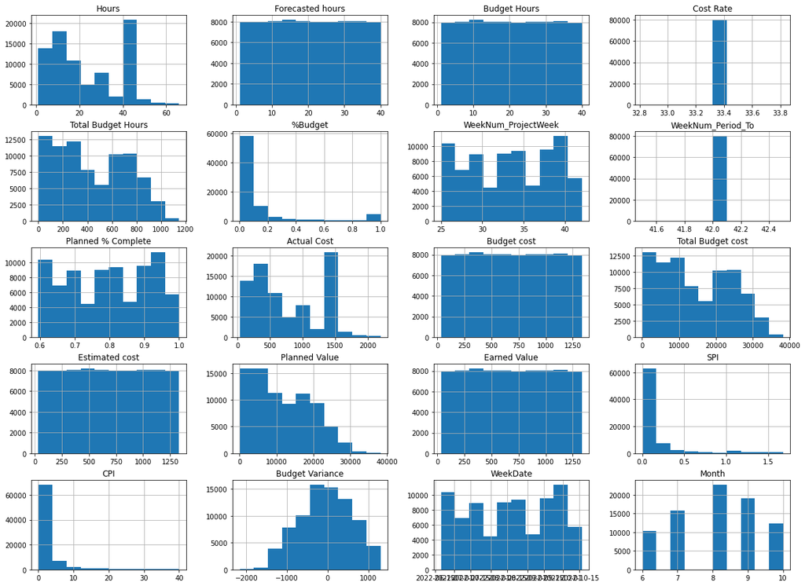

```python
Hours.hist( figsize=(20,15))
```

### What is the number of projects by status?

```
Project_Status
Closed                 49
Under POC             246
Post SOP              508
Under Acquisition     929
Open                 4517
Under Development    6001
Name: Project Code, dtype: int64
```

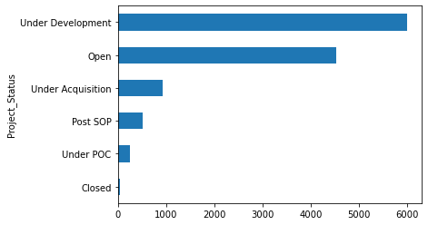

```python
ProjectsByStatus=Hours.groupby(['Project_Status'])['Project Code'].nunique().sort_values()
Project_Status_Month= Hours.groupby(['Month','Project_Status'])['Project Code'].nunique().reset_index(drop=False).sort_values(by=['Month','Project Code'],ascending=False)
print(ProjectsByStatus)
ProjectsByStatus.plot(kind='barh')
```

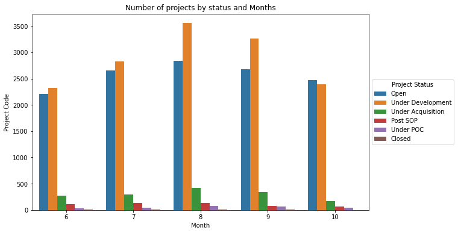

```python
fig = plt.figure(figsize=(10,6) )
sns.barplot(x='Month', y='Project Code',hue='Project_Status', data=Project_Status_Month)
plt.title("Number of projects by status and Months")
plt.legend(loc = 'center left', bbox_to_anchor=(1,0.5), title = 'Project Status')
```

- The biggest percentage of projects are "`under development`," followed by "`open`" and the lowest is "`closed`," which is not a good signal because closed projects should be the most numerous.Except for the `10th month`.

### What is the number of projects by Department?

```python
(Hours.groupby(['Project Code'])['Department'].nunique().sort_values()>1).sum()
```

```
0
```

- Can there be a project that has more than one department? `No`

```
Department
Wippers            5
Power Strain     234
Thermal          244
Services         870
Visibility      1058
Innovation      1302
Tooling         1706
Camera          1831
Switches        1880
Internal        1898
Name: Project Code, dtype: int64
```

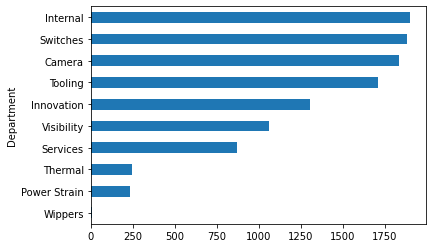

```python
ProjectsByDepartment= Hours.groupby(['Department'])['Project Code'].nunique().sort_values()
print(ProjectsByDepartment)
ProjectsByDepartment.plot(kind='barh')
```

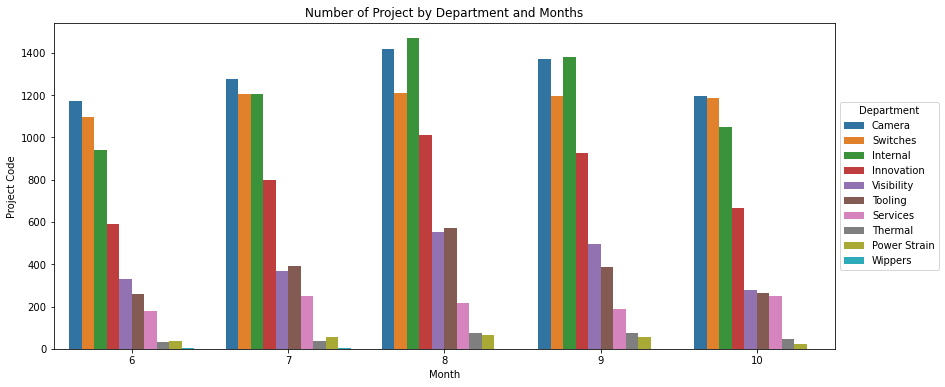

```python
Department_Month= Hours.groupby(['Department','Month'])['Project Code'].nunique().reset_index(drop=False).sort_values(by=['Month','Project Code'],ascending=False)
fig = plt.figure(figsize=(14,6) )
sns.barplot(x='Month', y='Project Code',hue='Department', data=Department_Month)
plt.title("Number of Project by Department and Months")
plt.legend(loc = 'center left', bbox_to_anchor=(1,0.5), title = 'Department')
```

### Department projects by status

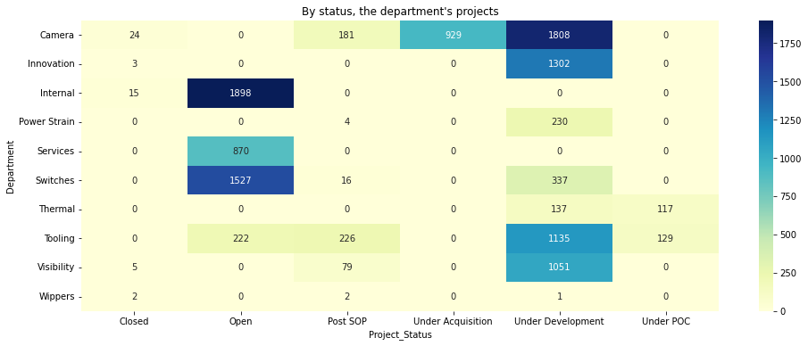

```python
df_pivot = pd.pivot_table(Hours, values='Project Code', index=['Department'],
                    columns=['Project_Status'],aggfunc=lambda x: len(x.unique()),fill_value=0)
fig = plt.figure(figsize=(16,6) )
swarm_plot = sns.heatmap(df_pivot, cmap="YlGnBu", annot=True,fmt=".0f")
plt.title("By status, the department's projects")

plt.show()
```

```python
print(Hours[Hours['Department']=='Internal']['Project Code'].nunique()/Hours['Project Code'].nunique()*100,'%')
```

```
17.210736307580703 %
```

- As indicated, the projects in the "Internal" area with the status "open" account for 17% of all projects. It should be noted that we are discussing projects with no repeat for each project number.

### `Actual Cost` Vs `Estimated Cost` By Department

|  | Department | Actual Cost | Estimated cost |
| --- | --- | --- | --- |
| 0 | Camera | 28101954.72 | 24789913.40 |
| 2 | Internal | 10649805.04 | 8848126.00 |
| 5 | Switches | 9637210.24 | 11744666.92 |
| 1 | Innovation | 6309341.92 | 5191922.40 |
| 8 | Visibility | 1996967.56 | 1760862.04 |
| 7 | Tooling | 1572070.92 | 1308543.04 |
| 4 | Services | 667099.72 | 797414.24 |
| 6 | Thermal | 188491.24 | 185325.84 |
| 3 | Power Strain | 173330.64 | 158003.44 |
| 9 | Wippers | 3365.32 | 3065.44 |

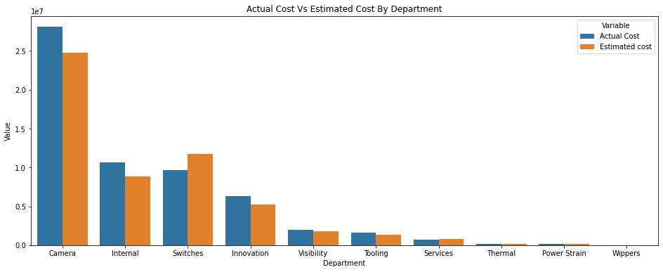

```python
Department_Cost= Hours.groupby(['Department'])[['Actual Cost','Estimated cost']].sum().reset_index(drop=False).sort_values(by=['Actual Cost'],ascending=False)
fig, ax1 = plt.subplots(figsize=(16, 6))
tidy = Department_Cost.melt(id_vars='Department').rename(columns=str.title)
sns.barplot(x='Department', y='Value', hue='Variable', data=tidy, ax=ax1)
plt.title("Actual Cost Vs Estimated Cost By Department")
Department_Cost
```

- The departments "Services " and "Switches" appear to have decent numbers, as the Actual Cost is less than the Estimated Cost.

```python
Hours[Hours['Project Code']=='0WK1000']
```

|  | Project Code | Project_Status | Calendar | Hours | Week | Forecasted hours | Budget Hours | Service type | Period_From | Period_To | ... | Budget cost | Total Budget cost | Estimated cost | Planned Value | Earned Value | SPI | CPI | Budget Variance | WeekDate | Month |
| --- | --- | --- | --- | --- | --- | --- | --- | --- | --- | --- | --- | --- | --- | --- | --- | --- | --- | --- | --- | --- | --- |
| 72511 | 0WK1000 | Under Development | EG_02 | 20 | 2022_W33 | 29 | 19 | NaN | 2022_W24 | 2022_W42 | ... | 633.08 | 3798.48 | 966.28 | 2984.52 | 633.08 | 0.212121 | 0.95 | -33.32 | 2022-08-15 | 8 |
| 72512 | 0WK1000 | Under Development | EG_02 | 40 | 2022_W37 | 9 | 18 | NaN | 2022_W24 | 2022_W42 | ... | 599.76 | 3798.48 | 299.88 | 3346.28 | 599.76 | 0.179232 | 0.45 | -733.04 | 2022-09-12 | 9 |
| 72513 | 0WK1000 | Under Development | EG_02 | 5 | 2022_W25 | 10 | 27 | NaN | 2022_W24 | 2022_W42 | ... | 899.64 | 3798.48 | 333.20 | 2261.00 | 899.64 | 0.397895 | 5.40 | 733.04 | 2022-06-20 | 6 |
| 72514 | 0WK1000 | Under Development | EG_02 | 20 | 2022_W25 | 14 | 38 | NaN | 2022_W24 | 2022_W42 | ... | 1266.16 | 3798.48 | 466.48 | 2261.00 | 1266.16 | 0.560000 | 1.90 | 599.76 | 2022-06-20 | 6 |
| 72515 | 0WK1000 | Under Development | EG_02 | 8 | 2022_W34 | 21 | 12 | NaN | 2022_W24 | 2022_W42 | ... | 399.84 | 3798.48 | 699.72 | 3074.96 | 399.84 | 0.130031 | 1.50 | 133.28 | 2022-08-22 | 8 |

5 rows × 28 columns

### Detect outlier

```python
def outlier(df_in, col_name):
    q1 = df_in[col_name].quantile(0.25)
    q3 = df_in[col_name].quantile(0.75)
    iqr = q3-q1 #Interquartile range
    fence_low  = q1-1.5*iqr
    fence_high = q3+1.5*iqr
    df_out = df_in.loc[~(df_in[col_name] > fence_low) & (df_in[col_name] < fence_high)]
    return df_out
```

### Let's get acquainted with the Actual ,Forecasted and Budget hours Distribution

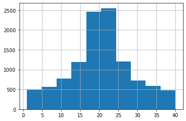

```python
Hours.groupby(['Project Code'])['Forecasted hours'].mean().hist()
```

```python
display(outlier( Hours, 'Hours'))
display(outlier( Hours, 'Forecasted hours'))
display(outlier( Hours, 'Budget Hours'))
```

|  | Project Code | Project_Status | Calendar | Hours | Week | Forecasted hours | Budget Hours | Service type | Period_From | Period_To | ... | Budget cost | Total Budget cost | Estimated cost | Planned Value | Earned Value | SPI | CPI | Budget Variance | WeekDate | Month |
| --- | --- | --- | --- | --- | --- | --- | --- | --- | --- | --- | --- | --- | --- | --- | --- | --- | --- | --- | --- | --- | --- |

0 rows × 28 columns

|  | Project Code | Project_Status | Calendar | Hours | Week | Forecasted hours | Budget Hours | Service type | Period_From | Period_To | ... | Budget cost | Total Budget cost | Estimated cost | Planned Value | Earned Value | SPI | CPI | Budget Variance | WeekDate | Month |
| --- | --- | --- | --- | --- | --- | --- | --- | --- | --- | --- | --- | --- | --- | --- | --- | --- | --- | --- | --- | --- | --- |

0 rows × 28 columns

|  | Project Code | Project_Status | Calendar | Hours | Week | Forecasted hours | Budget Hours | Service type | Period_From | Period_To | ... | Budget cost | Total Budget cost | Estimated cost | Planned Value | Earned Value | SPI | CPI | Budget Variance | WeekDate | Month |
| --- | --- | --- | --- | --- | --- | --- | --- | --- | --- | --- | --- | --- | --- | --- | --- | --- | --- | --- | --- | --- | --- |

0 rows × 28 columns

```python
Hours['Week'].unique()
```

```
array(['2022_W27', '2022_W35', '2022_W26', '2022_W36', '2022_W40',
       '2022_W34', '2022_W25', '2022_W42', '2022_W41', '2022_W29',
       '2022_W32', '2022_W30', '2022_W38', '2022_W39', '2022_W31',
       '2022_W37', '2022_W33', '2022_W28'], dtype=object)
```

- No outlier

```python
Engineering.head()
```

|  | Ticket Number | Project Code | Start Date | End Date | Stage | Site | Severity | Ticket Origin | Days |
| --- | --- | --- | --- | --- | --- | --- | --- | --- | --- |
| 0 | Tict1 | 0WK1000 | 2022-03-17 | 2022-09-01 | Closed | Russia | Red | Customer | 168 |
| 1 | Tict2 | 0WK1000 | 2022-08-08 | 2022-10-27 | Closed | Russia | Orange | Quality | 80 |
| 2 | Tict3 | 0WK1000 | 2022-06-30 | 2022-10-31 | Closed | Russia | Green | Customer | 123 |
| 3 | Tict4 | 0WK1000 | 2022-01-31 | 2022-09-26 | Under Implementation | Russia | Green | Quality | 238 |
| 4 | Tict5 | 0WK1000 | 2022-05-23 | 2022-10-03 | Closed | Russia | Orange | Supplier | 133 |

```python
Engineering.duplicated().sum()
```

```
0
```

### Assigning tags to the tickets based on completion time

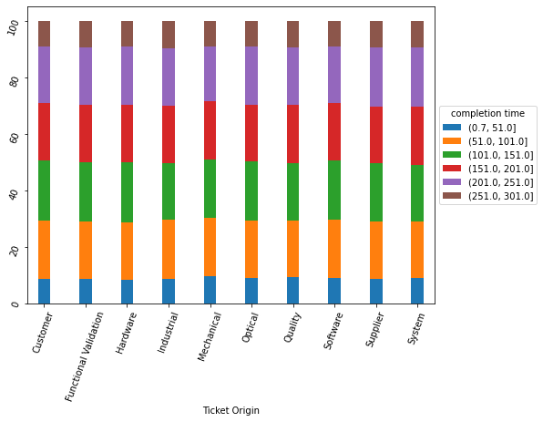

```python
Engineering["completion time"] = pd.cut(Engineering["Days"],bins=6)
ds = Engineering.groupby(['Ticket Origin','completion time'])['Ticket Number'].nunique().unstack()
ds.T
ax = (ds.T*100.0 / ds.T.sum()).T.plot(kind='bar',width = 0.3,stacked = True,rot = 0, figsize = (8,6))
ax.tick_params( rotation=70)

plt.legend(loc = 'center left', bbox_to_anchor=(1,0.5), title = 'completion time')
```

### Tickets by Severity and Ticket Origin

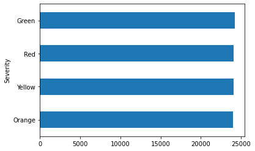

```python
ds = Engineering.groupby(['Severity'])['Ticket Number'].nunique().sort_values()
ds.plot(kind='barh')
```

| Severity Ticket Origin | Green | Orange | Red | Yellow |
| --- | --- | --- | --- | --- |
| Customer | 2356 | 2301 | 2438 | 2378 |
| Functional Validation | 2403 | 2445 | 2484 | 2394 |
| Hardware | 2506 | 2364 | 2469 | 2395 |
| Industrial | 2430 | 2506 | 2466 | 2384 |
| Mechanical | 2452 | 2451 | 2470 | 2400 |
| Optical | 2360 | 2342 | 2435 | 2402 |
| Quality | 2456 | 2412 | 2384 | 2485 |
| Software | 2397 | 2401 | 2376 | 2423 |
| Supplier | 2467 | 2464 | 2281 | 2375 |
| System | 2394 | 2332 | 2298 | 2452 |

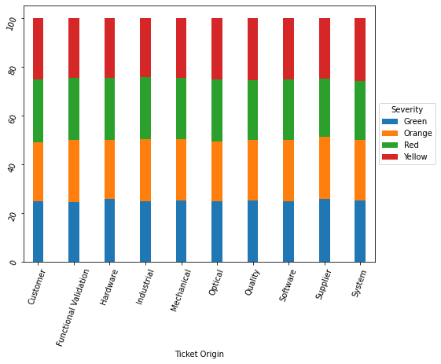

```python
ds = Engineering.groupby(['Ticket Origin','Severity'])['Ticket Number'].nunique().unstack()
ax = (ds.T*100.0 / ds.T.sum()).T.plot(kind='bar',width = 0.3,stacked = True,rot = 0, figsize = (8,6))
ax.tick_params( rotation=70)
plt.legend(loc = 'center left', bbox_to_anchor=(1,0.5), title = 'Severity')
ds
```

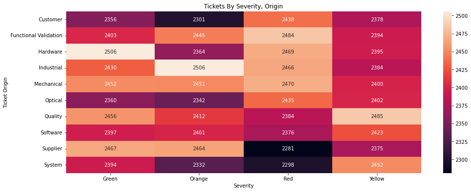

```python
df_pivot = pd.pivot_table(Engineering, values='Ticket Number', index=['Ticket Origin'],
                    columns=['Severity'],aggfunc=lambda x: len(x.unique()),fill_value=0)
fig = plt.figure(figsize=(16,6) )
swarm_plot = sns.heatmap(df_pivot, annot=True,fmt=".0f")
plt.title("Tickets By Severity, Origin")

plt.show()
```

### Tickets by Stage and Ticket Origin

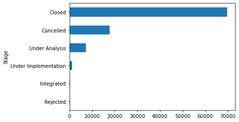

```python
ds = Engineering.groupby(['Stage'])['Ticket Number'].nunique().sort_values()
ds.plot(kind='barh')
```

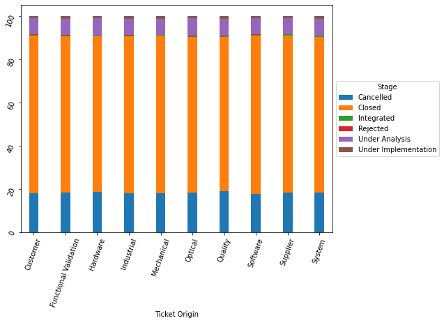

```python
ds = Engineering.groupby(['Ticket Origin','Stage'])['Ticket Number'].nunique().unstack()
ax = (ds.T*100.0 / ds.T.sum()).T.plot(kind='bar',width = 0.3,stacked = True,rot = 0, figsize = (8,6))
ax.tick_params( rotation=70)

plt.legend(loc = 'center left', bbox_to_anchor=(1,0.5), title = 'Stage')
```

### Tickets by Site and Ticket Origin

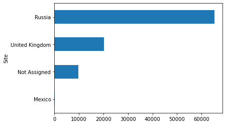

```python
ds = Engineering.groupby(['Site'])['Ticket Number'].nunique().sort_values()
ds.plot(kind='barh')
```

| Site Ticket Origin | Mexico | Not Assigned | Russia | United Kingdom |
| --- | --- | --- | --- | --- |
| Customer | 0.202235 | 10.367217 | 68.004258 | 21.426291 |
| Functional Validation | 0.113954 | 10.421631 | 67.668082 | 21.796333 |
| Hardware | 0.196912 | 10.457042 | 68.597782 | 20.748264 |
| Industrial | 0.237285 | 10.048489 | 68.637161 | 21.077066 |
| Mechanical | 0.206548 | 10.368687 | 68.770009 | 20.654756 |
| Optical | 0.137435 | 9.937626 | 68.358177 | 21.566762 |
| Quality | 0.237824 | 10.691759 | 67.831662 | 21.238755 |
| Software | 0.220241 | 10.424751 | 68.211851 | 21.143157 |
| Supplier | 0.241876 | 9.664528 | 69.018824 | 21.074771 |
| System | 0.212517 | 10.370843 | 68.430560 | 20.986080 |

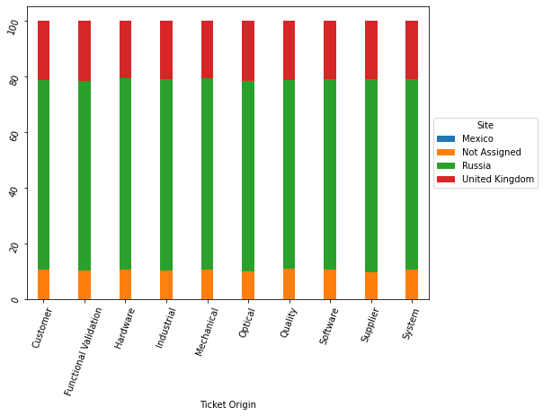

```python
ds = Engineering.groupby(['Ticket Origin','Site'])['Ticket Number'].nunique().unstack()
ax = (ds.T*100.0 / ds.T.sum()).T.plot(kind='bar',width = 0.3,stacked = True,rot = 0, figsize = (8,6))
ax.tick_params( rotation=70)

plt.legend(loc = 'center left', bbox_to_anchor=(1,0.5), title = 'Site')
(ds.T*100.0 / ds.T.sum()).T
```

### Tickets by Month when they were raised

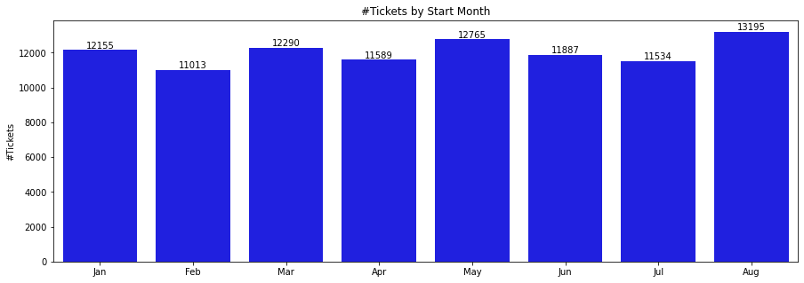

```python
month_group = Engineering.groupby(Engineering['Start Date'].dt.month)['Ticket Number'].count().reset_index()

plt.rcParams['figure.figsize'] = (15,5)
ax = sns.barplot(data = month_group, x = 'Start Date', y = 'Ticket Number', color = 'blue')
for index, row in month_group.iterrows():
    ax.text(row.name, row['Ticket Number'], row['Ticket Number'], ha = 'center', va = 'bottom')

plt.title('#Tickets by Start Month')
plt.xlabel(None)
plt.xticks(range(0,8), ['Jan','Feb','Mar','Apr','May','Jun','Jul','Aug'])
plt.ylabel('#Tickets')
plt.show()
```

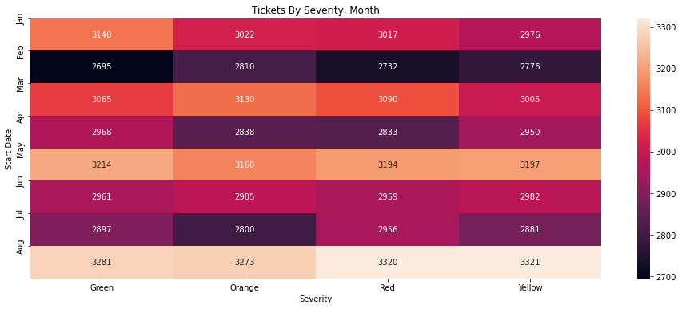

```python
df_pivot = pd.pivot_table(Engineering, values='Ticket Number', index=Engineering['Start Date'].dt.month,
                    columns=['Severity'],aggfunc=lambda x: len(x.unique()),fill_value=0)
fig = plt.figure(figsize=(16,6) )
swarm_plot = sns.heatmap(df_pivot, annot=True,fmt=".0f")
plt.title("Tickets By Severity, Month")
plt.yticks(range(0,8), ['Jan','Feb','Mar','Apr','May','Jun','Jul','Aug'])

plt.show()
```

### Tickets by Completion Time

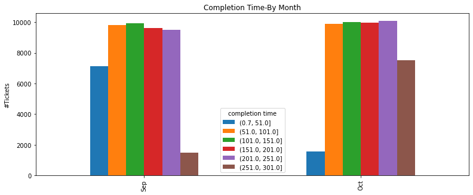

```python
plt.rcParams['figure.figsize'] = (13,5)

completion_time_pivot = pd.pivot_table(Engineering,values = 'Ticket Number', index = Engineering['End Date'].dt.month, columns = ['completion time'], aggfunc = 'count').fillna(0)
completion_time_pivot.plot(kind = 'bar')


plt.title('Completion Time-By Month')
plt.xlabel(None)
plt.ylabel('#Tickets')
plt.xticks(range(0,2), [ 'Sep','Oct' ])
plt.show()
```

### Despite the differences in characteristics, it appears that the proportions are equal and the patterns are consistent.

```python
def is_outlier(points, thresh=3.5):
    if len(points.shape) == 1:
        points = points[:,None]
    median = np.median(points, axis=0)
    diff = np.sum((points - median)**2, axis=-1)
    diff = np.sqrt(diff)
    med_abs_deviation = np.median(diff)

    modified_z_score = 0.6745 * diff / med_abs_deviation

    return modified_z_score > thresh
```

### Average number of Tickets per project

```python
CountOfTicketByProject = Engineering.groupby(Engineering['Project Code'])['Ticket Number'].count().reset_index()
print('Average number of Tickets per project :',CountOfTicketByProject['Ticket Number'].mean())
```

```
Average number of Tickets per project : 11.25049585812624
```

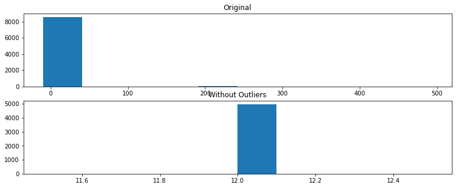

```python
# The function above... In my case it's in a local utilities module

# Generate some data
x = np.random.random(100)

# Append a few "bad" points
x = np.r_[CountOfTicketByProject['Ticket Number'], -3, -10, 100]

# Keep only the "good" points
# "~" operates as a logical not operator on boolean numpy arrays
filtered = x[~is_outlier(x)]

# Plot the results
fig, (ax1, ax2) = plt.subplots(nrows=2)

ax1.hist(x)
ax1.set_title('Original')

ax2.hist(filtered)
ax2.set_title('Without Outliers')

plt.show()
```

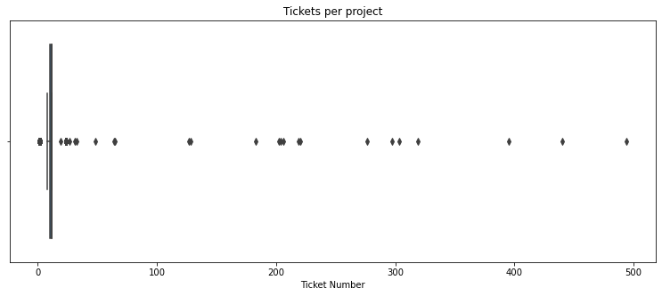

```python
sns.boxplot(x=CountOfTicketByProject['Ticket Number'])
plt.title('Tickets per project')
```

### Export data to represent conclusions via Power BI

```python
Hours.to_excel(r'../Clean Data/Hours_Data.xlsx')
Hours.to_excel(r'../Clean Data/Engineering_Data.xlsx')
```